# Using Clustering Techniques to Explore Theft Incidents from the Dallas Crime Dataset

### MSDS 7331 Data Mining Project 3

#### By Jean Jecha, Sharon Teo, Jessica Wheeler

# Introduction

From exploratory data analysis to using logistic regression, SVMs, gradient-based optomization, and various classification techniques, we have uncovered a lot of information from the Dallas Crime dataset. As mentioned in the previous projects, the Dallas Crime dataset consists of 196k rows in 102 attributes. We continue to narrow down the dataset and use incidents that occurred in 2016 as it contains the most complete data.

We took a closer look at theft incidents as one of our tasks for Project 2. Theft is an interesting subject in regards to this dataset as it was the highest occurring incident in Dallas in 2016. In Project 2, using logistic regression, we had found that the variables `disp_clear_time_m, IsDrugRelated, Watch_3, ComplainantRace_B, IsGangRelated,` and `Division_SouthEast` were all negative indicators of our response variable, `IsTheft.` On the other hand, `Hour, Watch_1, ComplainantRace_L, ComplainantRace_W,` and `rec_disp_time` were all positive indicators of theft.

# Contents

- Loading, Cleaning and Preprocessing the Data
- Clustering on Theft
- More Clustering
- Exceptional Work
  - Neural Network Using Keras
  - Theft Incidents on the Map
- Conclusion

Back to Top

## Loading, Cleaning, and Preprossessing the Data

After importing the neccessary packages and reading in the dataset, we cleaned the attribute titles and susbetted the data to include only incidents that occurred in 2016. Since there are so many attributes in this dataset, we chose a sample of variables to keep based on our interests for analysis. Specifically, we wanted to examine the following:

- Are theft incidents drug or gang related?
- How do theft incidents cluster with time-related attributes such as the recorded dispatch time? How about the time it takes to clear? What about the days of the week, and more specifically, the weekend?
- Are there certain areas or locations that get targeted more heavily than others?
- In regards to the complainant, does gender, race, or age have any clustering effect on theft?

The only information in the dataset about victims is `VictimCondition`, which isn't exacly relevant to what we are looking at since it applies more to violent crimes. Since we do not have more specific information about the victim, we use the complainant information for analysis. This may still give us good information as to who the targets of theft were. Usually, a person reports a theft incident when something of their own was stolen and/or broken into. Thus, we use information about the complainant to see what kinds of people are getting targeted and if there is any pattern.

In the code below, we converted `CallReceivedDateTime, CallClearedDateTime,` and `CallDispatchDateTime` into datetime type attributes. We created the variables `rec_disp_time_m` and `disp_clear_time_m` to describe the amount of time between when a call was received to the time officers were dispatched, and dispatch time to when the call was marked as clear, respectively. For theft incidents, clear time is usually when the items were found or recovered. We predict that this variable may cluster well with theft. Next we made sure that these variables only included positive values.

We converted `Time1ofOccurrence` into a variable called `Hour` to describe the hour of the day the incident occurred. We also made `DrugRelatedIncident` and `GangRelatedIncident` more usefuly by one-hot encoding them into the variables `IsDrugRelated` and `IsGangRelated`. Lastly, we created a variable called `IsWeekend` that represents if an incident occurred on a Friday or Saturday.

```python
# Import Crime data set
# Orginal dataset from https://www.dallasopendata.com/Public-Safety/Police-Incidents/tbnj-w5hb
import pandas as pd
import numpy as np
import seaborn as sns
%matplotlib inline
import matplotlib.pyplot as plt
from __future__ import print_function

# read in the csv file
df = pd.read_csv('/Users/sharonteo/Downloads/Police_Incidents.csv')

# Reference: http://stackoverflow.com/questions/11346283/renaming-columns-in-pandas
# Removing spaces from headers

df.columns = [x.strip().replace(' ', '') for x in df.columns]
df.columns = [x.strip().replace('/', '') for x in df.columns]
df.columns = [x.strip().replace('(', '') for x in df.columns]
df.columns = [x.strip().replace(')', '') for x in df.columns]
df.columns = [x.strip().replace('-', '') for x in df.columns]

#df.head()
# Subset the dataset to year 2016
# Ref: http://stackoverflow.com/questions/18172851/deleting-dataframe-row-in-pandas-based-on-column-value

df = df[df.Year1ofOccurrence == 2016]
df = df[df.ComplainantRace != 'TEST']
df = df[df.ComplainantGender != 'TEST']
#list(df)

df_theft = df[['CallReceivedDateTime','CallClearedDateTime','CallDispatchDateTime',
               'Time1ofOccurrence','DrugRelatedIncident','Watch','Month1ofOccurence',
               'ComplainantRace','ComplainantGender','ComplainantAge','Division',
               'Day1oftheWeek','GangRelatedOffense','UCROffenseDescription','XCoordinate',
               'YCoordinate']].copy()

df_theft['CallReceivedDateTime'] = pd.to_datetime(df_theft['CallReceivedDateTime'])
df_theft['CallClearedDateTime'] = pd.to_datetime(df_theft['CallClearedDateTime'])
df_theft['CallDispatchDateTime'] = pd.to_datetime(df_theft['CallDispatchDateTime'])

# Compute the time between call received and call displatched, call Displatch and call cleared.
# Reference: http://www.itgo.me/a/x791470639852744898/calculate-pandas-dataframe-time-difference-between-two-columns-in-hours-and-minu
df_theft['rec_disp_time_m'] = (df_theft['CallDispatchDateTime'] - df_theft['CallReceivedDateTime']).astype('timedelta64[m]')
df_theft['disp_clear_time_m'] = (df_theft['CallClearedDateTime'] - df_theft['CallDispatchDateTime']).astype('timedelta64[m]')

# Remove rows with negative time difference
df_theft = df_theft[df_theft.rec_disp_time_m >= 0]
df_theft = df_theft[df_theft.disp_clear_time_m >= 0]

# Create Hour of Occurrence from Time Occurrence
# Ref: http://stackoverflow.com/questions/25789445/pandas-make-new-column-from-string-slice-of-another-column
df_theft['Hour'] = df_theft.Time1ofOccurrence.str[:2]
df_theft['Hour'] = (df_theft['Hour']).astype('float64')

# change Drug Related attribute to a more usable value
df_theft['IsDrugRelated'] = df_theft.DrugRelatedIncident == 'Yes'
df_theft.IsDrugRelated = df_theft.IsDrugRelated.astype(np.int)

# change Gang Related attribute to a more usable value
df_theft['IsGangRelated'] = df_theft.GangRelatedOffense == 'Yes'
df_theft.IsGangRelated = df_theft.IsGangRelated.astype(np.int)

# Change day of week to indicate weekend
df_theft['IsWeekend'] = (df_theft['Day1oftheWeek'] == 'Sat') | (df_theft['Day1oftheWeek'] == 'Fri')
df_theft.IsWeekend = df_theft.IsWeekend.astype(np.int)

# Remove call datetime call columns
for col in ['CallReceivedDateTime','CallClearedDateTime','CallDispatchDateTime',
            'Time1ofOccurrence','Day1oftheWeek','GangRelatedOffense']:
    if col in df_theft:
        del df_theft[col]

df_theft.head()
```

|  | DrugRelatedIncident | Watch | Month1ofOccurence | ComplainantRace | ComplainantGender | ComplainantAge | Division | UCROffenseDescription | XCoordinate | YCoordinate | rec_disp_time_m | disp_clear_time_m | Hour | IsDrugRelated | IsGangRelated | IsWeekend |
| --- | --- | --- | --- | --- | --- | --- | --- | --- | --- | --- | --- | --- | --- | --- | --- | --- |
| 0 | UNK | 3 | December | L | F | 17.0 | Central | CRIMINAL MISCHIEF/VANDALISM | 2.502764e+06 | 6.975903e+06 | 0.0 | 207.0 | 23.0 | 0 | 0 | 1 |
| 1 | UNK | 3 | December | L | M | 32.0 | Central | CRIMINAL MISCHIEF/VANDALISM | 2.502764e+06 | 6.975903e+06 | 0.0 | 207.0 | 23.0 | 0 | 0 | 1 |
| 2 | UNK | 3 | December | W | F | NaN | Central | CRIMINAL MISCHIEF/VANDALISM | NaN | NaN | 0.0 | 207.0 | 23.0 | 0 | 0 | 1 |
| 3 | UNK | U | December | C | F | 30.0 | NorthEast | CRIMINAL MISCHIEF/VANDALISM | 2.510452e+06 | 7.008107e+06 | 0.0 | 439.0 | 12.0 | 0 | 0 | 0 |
| 5 | No | 3 | December | L | M | 26.0 | SouthEast | ASSAULT | 2.524838e+06 | 6.958656e+06 | 3.0 | 122.0 | 23.0 | 0 | 0 | 1 |

### Imputing the variables

We imputed the dataset using group medians. For the attributes `ComplainantRace, ComplainantGender,` and `Division`, any NAs were filled using the highest occurring values. The complainant's age variable was separated according to an age range in `ComplainantAgeRange`.

```python
# creating missing values (imputing) grouping by day of week and watch
df_grouped = df_theft.groupby(by=['Month1ofOccurence','Watch'])

# Using grouping to impute data in each group and then transform back
# Impute missing numerical values
df_imputed = df_grouped.transform(lambda grp: grp.fillna(grp.median()))

# Impute missing categorical values
# Ref: http://stackoverflow.com/questions/32617811/imputation-of-missing-values-for-categories-in-pandas

# Impute missing values for complainant race
df_imputed['ComplainantRace'] = df_grouped.ComplainantRace.fillna(df_theft['ComplainantRace'].value_counts().index[0])

# Impute missing values for complainant gender
df_imputed['ComplainantGender'] = df_grouped.ComplainantGender.fillna(df_theft['ComplainantGender'].value_counts().index[0])

# Impute missing values for Division
df_imputed['Division'] = df_grouped.Division.fillna(df_theft['Division'].value_counts().index[0])

# break age into groups
df_imputed['ComplainantAgeRange'] = pd.cut(df_imputed.ComplainantAge,[0,16,24,65,1e6],4,labels=[0,1,2,3])
df_imputed['ComplainantAgeRange'] = (df_imputed['ComplainantAgeRange']).astype('int64')

# Filling the grouped variables from original data frame
df_imputed[['Month1ofOccurence','Watch','UCROffenseDescription','DrugRelatedIncident']] = df_theft[['Month1ofOccurence','Watch','UCROffenseDescription','DrugRelatedIncident']]

# Create imputed file for KMode analysis
df_imputed_KMode = df_imputed[['ComplainantAgeRange','ComplainantAge','ComplainantRace',
                      'ComplainantGender','Division','Watch','UCROffenseDescription',
                      'Hour','IsDrugRelated']].copy()

# Plot data for all
df_Plot = df_imputed[['XCoordinate','YCoordinate']].copy()

# Plot data for Theft only
tmp_theft = df_imputed[df_imputed.UCROffenseDescription == 'THEFT']
df_Plot_theft = tmp_theft[['XCoordinate','YCoordinate']].copy()

# Plot data for drug related crimes
tmp_drug = df_imputed[df_imputed.DrugRelatedIncident == 'Yes']
df_Plot_drug = tmp_drug[['XCoordinate','YCoordinate']].copy()

# Remove call datetime call columns
for col in ['DrugRelatedIncident']:
    if col in df_imputed:
        del df_imputed[col]

df_imputed.info()
```

```
<class 'pandas.core.frame.DataFrame'>
Int64Index: 99427 entries, 0 to 196850
Data columns (total 16 columns):
ComplainantAge           99427 non-null float64
XCoordinate              99427 non-null float64
YCoordinate              99427 non-null float64
rec_disp_time_m          99427 non-null float64
disp_clear_time_m        99427 non-null float64
Hour                     99427 non-null float64
IsDrugRelated            99427 non-null int64
IsGangRelated            99427 non-null int64
IsWeekend                99427 non-null int64
ComplainantRace          99427 non-null object
ComplainantGender        99427 non-null object
Division                 99427 non-null object
ComplainantAgeRange      99427 non-null int64
Month1ofOccurence        99427 non-null object
Watch                    99427 non-null object
UCROffenseDescription    99427 non-null object
dtypes: float64(6), int64(4), object(6)
memory usage: 12.9+ MB
```

Next we created dummy variables from the categorical variables for `ComplainantRace, ComplainantGender, Division,` and `Watch.` This creates more specific attributes for each category so that we can see which ones cluster well with theft and which ones do not.

```python
# Generating dummy variables from categorical variables

# create dummy variables for Complainant Race
tmp_df = pd.get_dummies(df_imputed.ComplainantRace,prefix='ComplainantRace')
df_imputed = pd.concat((df_imputed,tmp_df),axis=1) # add back into the dataframe

# create dummy variables for Complainant Race
tmp_df = pd.get_dummies(df_imputed.ComplainantGender,prefix='ComplainantGender')
df_imputed = pd.concat((df_imputed,tmp_df),axis=1) # add back into the dataframe

# create dummy variables for Division
tmp_df = pd.get_dummies(df_imputed.Division,prefix='Division')
df_imputed = pd.concat((df_imputed,tmp_df),axis=1) # add back into the dataframe

# create dummy variables for Watch
tmp_df = pd.get_dummies(df_imputed.Watch,prefix='Watch')
df_imputed = pd.concat((df_imputed,tmp_df),axis=1) # add back into the dataframe

# Remove columns used for dummy variables
for col in ['Watch','Division','ComplainantRace','ComplainantGender','Month1ofOccurence']:
    if col in df_imputed:
        del df_imputed[col]

df_imputed.info()
```

```
<class 'pandas.core.frame.DataFrame'>
Int64Index: 99427 entries, 0 to 196850
Data columns (total 33 columns):
ComplainantAge            99427 non-null float64
XCoordinate               99427 non-null float64
YCoordinate               99427 non-null float64
rec_disp_time_m           99427 non-null float64
disp_clear_time_m         99427 non-null float64
Hour                      99427 non-null float64
IsDrugRelated             99427 non-null int64
IsGangRelated             99427 non-null int64
IsWeekend                 99427 non-null int64
ComplainantAgeRange       99427 non-null int64
UCROffenseDescription     99427 non-null object
ComplainantRace_A         99427 non-null uint8
ComplainantRace_B         99427 non-null uint8
ComplainantRace_C         99427 non-null uint8
ComplainantRace_I         99427 non-null uint8
ComplainantRace_L         99427 non-null uint8
ComplainantRace_N         99427 non-null uint8
ComplainantRace_U         99427 non-null uint8
ComplainantRace_W         99427 non-null uint8
ComplainantGender_F       99427 non-null uint8
ComplainantGender_M       99427 non-null uint8
ComplainantGender_U       99427 non-null uint8
Division_Central          99427 non-null uint8
Division_North Central    99427 non-null uint8
Division_NorthEast        99427 non-null uint8
Division_NorthWest        99427 non-null uint8
Division_South Central    99427 non-null uint8
Division_SouthEast        99427 non-null uint8
Division_SouthWest        99427 non-null uint8
Watch_1                   99427 non-null uint8
Watch_2                   99427 non-null uint8
Watch_3                   99427 non-null uint8
Watch_U                   99427 non-null uint8
dtypes: float64(6), int64(4), object(1), uint8(22)
memory usage: 11.2+ MB
```

Next we created a variable called `IsTheft` using the `UCROffenseDescription` wherein a 1 is indicative of a theft incident versus a 0 if it is not classified as such.

```python
df_imputed['IsTheft'] = df_imputed.UCROffenseDescription == 'THEFT'
df_imputed.IsTheft = df_imputed.IsTheft.astype(np.int)
```

```python
for col in ['UCROffenseDescription']:
    if col in df_imputed:
        del df_imputed[col]

df_imputed.info()
```

```
<class 'pandas.core.frame.DataFrame'>
Int64Index: 99427 entries, 0 to 196850
Data columns (total 33 columns):
ComplainantAge            99427 non-null float64
XCoordinate               99427 non-null float64
YCoordinate               99427 non-null float64
rec_disp_time_m           99427 non-null float64
disp_clear_time_m         99427 non-null float64
Hour                      99427 non-null float64
IsDrugRelated             99427 non-null int64
IsGangRelated             99427 non-null int64
IsWeekend                 99427 non-null int64
ComplainantAgeRange       99427 non-null int64
ComplainantRace_A         99427 non-null uint8
ComplainantRace_B         99427 non-null uint8
ComplainantRace_C         99427 non-null uint8
ComplainantRace_I         99427 non-null uint8
ComplainantRace_L         99427 non-null uint8
ComplainantRace_N         99427 non-null uint8
ComplainantRace_U         99427 non-null uint8
ComplainantRace_W         99427 non-null uint8
ComplainantGender_F       99427 non-null uint8
ComplainantGender_M       99427 non-null uint8
ComplainantGender_U       99427 non-null uint8
Division_Central          99427 non-null uint8
Division_North Central    99427 non-null uint8
Division_NorthEast        99427 non-null uint8
Division_NorthWest        99427 non-null uint8
Division_South Central    99427 non-null uint8
Division_SouthEast        99427 non-null uint8
Division_SouthWest        99427 non-null uint8
Watch_1                   99427 non-null uint8
Watch_2                   99427 non-null uint8
Watch_3                   99427 non-null uint8
Watch_U                   99427 non-null uint8
IsTheft                   99427 non-null int64
dtypes: float64(6), int64(5), uint8(22)
memory usage: 11.2 MB
```

Back to Top

## Clustering on Theft

To start, we used the `StratifiedKFold` function from `scikit-learn` and chose to do 10 splits. This way we can cross-validate the data using training and testing sets. A Random Forest Classifier algorithm is used and the average accuracy of classifying whether an incident is theft or not is shown below. This gives us our baseline classification performance with all of the variables we decided to keep, based on our results from Project 2.

```python
# Response variable of IsTheft
# significant variables from project 2
from sklearn.model_selection import StratifiedKFold, cross_val_score
from sklearn.ensemble import RandomForestClassifier

y = df_imputed['IsTheft']
X = df_imputed[['Watch_3','Watch_2','Watch_1','Hour','disp_clear_time_m',
                'rec_disp_time_m','ComplainantGender_F','ComplainantGender_M',
                'IsDrugRelated','ComplainantRace_B','ComplainantRace_L',
                'ComplainantRace_W','Division_SouthEast','ComplainantAgeRange',
                'ComplainantAge']]

cv = StratifiedKFold(n_splits=10)

clf = RandomForestClassifier(n_estimators=150,random_state=1)

acc = cross_val_score(clf,X,y=y,cv=cv)

print ("Average accuracy = ", acc.mean()*100, "+-", acc.std()*100)
```

```
Average accuracy =  76.483715791 +- 0.705957439256
```

We can see that the accuracy of this model is about 76.48 with a standard deviation of +/- 0.705. Below we used KMeans clustering with the parameters as shown:

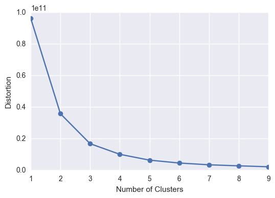

```python
# Reference: "Python Machine Learning by Sebastian Raschka"
# plot for estimated number of clusters
from matplotlib import pyplot as plt
from sklearn.cluster import KMeans

X=df_imputed[['Watch_3','Watch_2','Watch_1','Hour','disp_clear_time_m',
              'rec_disp_time_m','ComplainantGender_F','ComplainantGender_M',
              'IsDrugRelated','ComplainantRace_B','ComplainantRace_L',
              'ComplainantRace_W','Division_SouthEast','ComplainantAgeRange',
              'ComplainantAge']]

distortions = []
for i in range(1, 10):
    km = KMeans(n_clusters = i,
               init='k-means++',
               n_init=10,
               max_iter=300,
               random_state=0)
    km.fit(X)
    distortions.append(km.inertia_)

plt.plot(range(1,10), distortions, marker='o')
plt.xlabel('Number of Clusters')
plt.ylabel('Distortion')
plt.show()
```

The graph above shows the distortion vs. number of clusters. This determines the number of clusters for maximum efficiency and minimum error. Based on the graph, we chose to use KMeans clustering with 3 clusters - results shown below. To note, we also tried using 4 clusters but the same results were achieved so we omitted those results.

We started by grouping similar variables into one with the rest in another, keeping our `IsTheft` variable as the response. Thus, X1- the first group- consists of all of the `Watch` categories as well as `Hour` to represent the time-based variables.

```python
# Using KMeans
# X1 using Watch and hour
# Using number of clusters (n_clusters) from above graph

import numpy as np
import pandas as pd

X1 = df_imputed[['Watch_3','Watch_1','Watch_2','Hour']]

cls = KMeans(n_clusters=3, init='k-means++',random_state=1)
cls.fit(X1)
newfeature = cls.labels_ # the labels from kmeans clustering

y = df_imputed['IsTheft']
X = df_imputed[['disp_clear_time_m','IsDrugRelated',
                'ComplainantRace_B','ComplainantRace_L','ComplainantRace_W','ComplainantGender_F',
                'ComplainantGender_M','rec_disp_time_m','Division_SouthEast','ComplainantAgeRange',
                'ComplainantAge']]
X = np.column_stack((X,pd.get_dummies(newfeature)))

acc = cross_val_score(clf,X,y=y,cv=cv)

print ("Average accuracy (with kmeans for Watch/Variables)= ", acc.mean()*100, "+-", acc.std()*100)
```

```
Average accuracy (with kmeans for Watch/Variables)=  73.1919866247 +- 0.584401727254
```

The average accuracy clustering the variables above with theft is about 73% +/- 0.58. From our previous results, `Watch_2` was not found to have an effect on the models generated so let's see what happens when we remove that variable:

```python
# Removed Watch_2 from X1

X1 = df_imputed[['Watch_3','Watch_1','Hour']]

cls = KMeans(n_clusters=3, init='k-means++',random_state=1)
cls.fit(X1)
newfeature = cls.labels_ # the labels from kmeans clustering

y = df_imputed['IsTheft']
X = df_imputed[['disp_clear_time_m','IsDrugRelated',
                'ComplainantRace_B','ComplainantRace_L','ComplainantRace_W','ComplainantGender_F',
                'ComplainantGender_M','rec_disp_time_m','Division_SouthEast','ComplainantAgeRange',
                'ComplainantAge']]
X = np.column_stack((X,pd.get_dummies(newfeature)))

acc = cross_val_score(clf,X,y=y,cv=cv)

print ("Average accuracy (with kmeans for X1/X)= ", acc.mean()*100, "+-", acc.std()*100)
```

```
Average accuracy (with kmeans for X1/X)=  73.1919866247 +- 0.584401727254
```

The resulting average accuracy is the same as previously. However, on another run, the accuracy showed improvement, although it was marginal.

Now let's see what happens when we remove the other time related variables- the dispatch time and the clear time.

```python
# Removed disp_clear_time_m and rec_disp_time_m
X1 = df_imputed[['Watch_3','Watch_1','Hour']]

cls = KMeans(n_clusters=3, init='k-means++',random_state=1)
cls.fit(X1)
newfeature = cls.labels_ # the labels from kmeans clustering

y = df_imputed['IsTheft']
X = df_imputed[['IsDrugRelated','ComplainantRace_B','ComplainantRace_L',
                'ComplainantRace_W','Division_SouthEast']]
X = np.column_stack((X,pd.get_dummies(newfeature)))

acc = cross_val_score(clf,X,y=y,cv=cv)

print ("Average accuracy (with kmeans for X1/X)= ", acc.mean()*100, "+-", acc.std()*100)
```

```
Average accuracy (with kmeans for X1/X)=  75.7038952305 +- 0.00291898445905
```

Now we see an improvement of accuracy at 75.7% with a much lower standard deviation of +/- 0.0029. It seems that grouping `Watch_1, Watch_3,` and `Hour` in one group and the remaining variables that have to do with drug relation, complainant race, and the SouthEast Division, in another group result in a higher clustering accuracy.

But, since the variables `rec_disp_time_m` and `rec_clear_time_m` have to do with time, let's put them in our first group and see how that performs.

```python
# Removed dist_clear_time_m and red_disp_time_m from X
# Adding all time related variables to X1
X1 = df_imputed[['Watch_3','Watch_2','Watch_1','Hour',
                 'disp_clear_time_m','rec_disp_time_m']]

cls = KMeans(n_clusters=3, init='k-means++',random_state=1)
cls.fit(X1)
newfeature = cls.labels_ # the labels from kmeans clustering

y = df_imputed['IsTheft']
X = df_imputed[['IsDrugRelated','ComplainantRace_B','ComplainantRace_L',
                'ComplainantRace_W','Division_SouthEast']]
X = np.column_stack((X,pd.get_dummies(newfeature)))

acc = cross_val_score(clf,X,y=y,cv=cv)

print ("Average accuracy (with kmeans for X1/X)= ", acc.mean()*100, "+-", acc.std()*100)
```

```
Average accuracy (with kmeans for X1/X)=  75.7038952305 +- 0.00291898445905
```

The resulting accuracy is about the same as it was before. Let's remove `Watch_2` as we did before to see if that has any effect.

```python
# Removed removed Watch_2 from X1 and didn't seem to change
X1 = df_imputed[['Watch_3','Watch_1','Hour',
                 'disp_clear_time_m','rec_disp_time_m']]

cls = KMeans(n_clusters=3, init='k-means++',random_state=1)
cls.fit(X1)
newfeature = cls.labels_ # the labels from kmeans clustering

y = df_imputed['IsTheft']
X = df_imputed[['IsDrugRelated','ComplainantRace_B','ComplainantRace_L',
                'ComplainantRace_W','Division_SouthEast']]
X = np.column_stack((X,pd.get_dummies(newfeature)))

acc = cross_val_score(clf,X,y=y,cv=cv)

print ("Average accuracy (with kmeans for X1/X)= ", acc.mean()*100, "+-", acc.std()*100)
```

```
Average accuracy (with kmeans for X1/X)=  75.7038952305 +- 0.00291898445905
```

Removing `Watch_2` did not have any effect on improving the accuracy or the standard deviation. Now let's take out `rec_disp_time_m` and `rec_clear_time_m` from the first group.

```python
# Removed dist_clear_time_m and red_disp_time_m from X1

X1 = df_imputed[['Watch_3','Watch_1','Hour']]

cls = KMeans(n_clusters=3, init='k-means++',random_state=1)
cls.fit(X1)
newfeature = cls.labels_ # the labels from kmeans clustering

y = df_imputed['IsTheft']
X = df_imputed[['IsDrugRelated','ComplainantRace_B','ComplainantRace_L',
                'ComplainantRace_W','Division_SouthEast',
                'ComplainantGender_F','ComplainantGender_M']]
X = np.column_stack((X,pd.get_dummies(newfeature)))

acc = cross_val_score(clf,X,y=y,cv=cv)

print ("Average accuracy (with kmeans for X1/X)= ", acc.mean()*100, "+-", acc.std()*100)
```

```
Average accuracy (with kmeans for X1/X)=  75.699859718 +- 0.00867745395353
```

The resulting average accuracy went down a little but and the standard deviation went from 0.003 to 0.0086. Nevertheless, taking those variables out did not result in a huge change. Let's play around with the variables a bit more and now take into account the effect of taking out `ComplainantRace_W` as well as `ComplainantGender_M`.

```python
# removed ComplainantRace_W and ComplainantGender_M
X1 = df_imputed[['Watch_3','Watch_1','Hour']]

cls = KMeans(n_clusters=3, init='k-means++',random_state=1)
cls.fit(X1)
newfeature = cls.labels_ # the labels from kmeans clustering

y = df_imputed['IsTheft']
X = df_imputed[['IsDrugRelated','ComplainantRace_B','ComplainantRace_L','Division_SouthEast',
               'ComplainantGender_F']]
X = np.column_stack((X,pd.get_dummies(newfeature)))

acc = cross_val_score(clf,X,y=y,cv=cv)

print ("Average accuracy (with kmeans for X1/X)= ", acc.mean()*100, "+-", acc.std()*100)
```

```
Average accuracy (with kmeans for X1/X)=  75.7038952305 +- 0.00291898445905
```

Again, our results are back to about 75.7% +/- 0.0029, which made a little bit of an improvement but again, nothing very significant. Now let's take out `Watch_1` and `ComplainantGender_F` from the list of variables and see what happens.

```python
#Removed Watch_1 from X1 and ComplainantGender_F from X
# so far this is our best mean and std
X1 = df_imputed[['Watch_3','Hour']]

cls = KMeans(n_clusters=3, init='k-means++',random_state=1)
cls.fit(X1)
newfeature = cls.labels_ # the labels from kmeans clustering

y = df_imputed['IsTheft']
X = df_imputed[['IsDrugRelated','ComplainantRace_B',
                'ComplainantRace_L','Division_SouthEast']]
X = np.column_stack((X,pd.get_dummies(newfeature)))

acc = cross_val_score(clf,X,y=y,cv=cv)

print ("Average accuracy (with kmeans for X1/X)= ", acc.mean()*100, "+-", acc.std()*100)
```

```
Average accuracy (with kmeans for X1/X)=  75.7038952305 +- 0.00291898445905
```

Average accuracy is staying constant at about 75.7 +/- 0.0029.

Let's explore what happens when we cluster `Watch_3` and `Hour` into one group and `IsDrugRelated` into another, of course keeping our `IsTheft` response variable.

```python
# Now lets try X1 as Watch_3, Hour with X only being IsDrugRelated
X1 = df_imputed[['Watch_3','Hour']]

cls = KMeans(n_clusters=3, init='k-means++',random_state=1)
cls.fit(X1)
newfeature = cls.labels_ # the labels from kmeans clustering

y = df_imputed['IsTheft']
X = df_imputed[['IsDrugRelated']]
X = np.column_stack((X,pd.get_dummies(newfeature)))

acc = cross_val_score(clf,X,y=y,cv=cv)

print ("Average accuracy (with kmeans for X1/X)= ", acc.mean()*100, "+-", acc.std()*100)
```

```
Average accuracy (with kmeans for X1/X)=  75.7038952305 +- 0.00291898445905
```

Narrowing down those variables didn't seem to make a difference. From this we may conclude that race and division don't seem to have an effect on clustering accuracy. However, we do believe that these are important variables so we'll experiment with new groups. In the code below, we placed `IsDrugRelated, ComplainantRace_B, ComplainantRace_L` and `DivisionSouthEast` in one group and a couple of our time variables, `Watch_3` and `Hour` into another group.

```python
# Swapping X1 and X variables
# Renaming X1 to X2

X2 = df_imputed[['IsDrugRelated','ComplainantRace_B',
                 'ComplainantRace_L','Division_SouthEast']]

cls = KMeans(n_clusters=3, init='k-means++',random_state=1)
cls.fit(X2)
newfeature = cls.labels_ # the labels from kmeans clustering

y = df_imputed['IsTheft']
X = df_imputed[['Watch_3','Hour']]
X = np.column_stack((X,pd.get_dummies(newfeature)))

acc = cross_val_score(clf,X,y=y,cv=cv)

print ("Average accuracy (with kmeans for X2/X)= ", acc.mean()*100, "+-", acc.std()*100)
```

```
Average accuracy (with kmeans for X2/X)=  77.7073909292 +- 0.213089097432
```

This different group of clustering resulted in a higher average accuracy of 77.7% +/- 0.213.

Now let's run a for-loop to find clusters that range from 1 to 3 for group 1 (X1), and clusters that range from 8 to 12 for group 2 (X2).

```python
# Using number of cluster range for X1 between 1 and 4, and cluster range between 8 and 12
X1 = df_imputed[['Watch_3','Hour']]
X2 = df_imputed[['ComplainantRace_B',
                 'ComplainantRace_L',
                 'Division_SouthEast']]

params = []

for n_time in range(1,4):
    for n_var in range(8,13):
        # get the first clustering
        cls_time = KMeans(n_clusters=n_time, init='k-means++',random_state=1)
        cls_time.fit(X1)
        newfeature_time = cls_time.labels_ # the labels from kmeans clustering

        # append on the second clustering
        cls_var = KMeans(n_clusters=n_var, init='k-means++',random_state=1)
        cls_var.fit(X2)
        newfeature_var = cls_var.labels_ # the labels from kmeans clustering

        y = df_imputed['IsTheft']
        X = df_imputed[['IsDrugRelated']]

        X = np.column_stack((X,pd.get_dummies(newfeature_fare),pd.get_dummies(newfeature_fam)))

        acc = cross_val_score(clf,X,y=y,cv=cv)
        params.append((n_fare,n_fam,acc.mean()*100,acc.std()*100)) # save state

        print ("Clusters",n_time,n_var,"Average accuracy = ", acc.mean()*100, "+-", acc.std()*100)
```

```
Clusters 1 8 Average accuracy =  75.7038952305 +- 0.00291898445905
Clusters 1 9 Average accuracy =  75.7038952305 +- 0.00291898445905
Clusters 1 10 Average accuracy =  75.7038952305 +- 0.00291898445905
Clusters 1 11 Average accuracy =  75.7038952305 +- 0.00291898445905
Clusters 1 12 Average accuracy =  75.7038952305 +- 0.00291898445905
Clusters 2 8 Average accuracy =  75.7038952305 +- 0.00291898445905
Clusters 2 9 Average accuracy =  75.7038952305 +- 0.00291898445905
Clusters 2 10 Average accuracy =  75.7038952305 +- 0.00291898445905
Clusters 2 11 Average accuracy =  75.7038952305 +- 0.00291898445905
Clusters 2 12 Average accuracy =  75.7038952305 +- 0.00291898445905
Clusters 3 8 Average accuracy =  75.7038952305 +- 0.00291898445905
Clusters 3 9 Average accuracy =  75.7038952305 +- 0.00291898445905
Clusters 3 10 Average accuracy =  75.7038952305 +- 0.00291898445905
Clusters 3 11 Average accuracy =  75.7038952305 +- 0.00291898445905
Clusters 3 12 Average accuracy =  75.7038952305 +- 0.00291898445905
```

Originally, this grouping included `ComplainantAge` which resulted in all of the same average accuracies and standard deviation but since we had not standardized that variable, we took it out to see if our results might change. It seems that regardless of cluster number for each of the groups, the same or very similar clustering results.

Back to Top

## More Clustering

In this section, we will create a few visualizations of how certain variables in the dataset cluster with one another using kmeans, mini-batch kmeans, and DBSCAN. We also deploy the Kmodes algorithm that is ideal for categorical data. (This may be considered as excpetional work.)

In the code below, we call StandardScaler from scikit-learn in order to standardize the variables in our imputed dataset. With this we can create a visualization of the different clusters when looking at `rec_disp_time_m` versus `Hour`. Note that this is a step back from what we've been focusing on, which was just theft. Now we are looking at these two variables with regards to all of the incidents in Dallas in 2016.

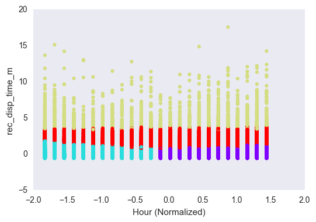

```python
# Plotting clustering for hour and rec_disp_time_m
from sklearn.preprocessing import StandardScaler
from matplotlib import pyplot as plt

X1 = df_imputed[['rec_disp_time_m','Hour']]

scl_obj = StandardScaler()
scl_obj.fit(X1)

X1_scaled = scl_obj.transform(X1)

n_var=4

cls_var = KMeans(n_clusters=n_var, init='k-means++',random_state=1)
cls_var.fit(X1_scaled)
newfeature_var = cls_var.labels_ # the labels from kmeans clustering

#X1=X1.values
plt.figure()
plt.scatter(X1_scaled[:, 1], X1_scaled[:, 0]+np.random.random(X1_scaled[:, 0].shape)/2, c=newfeature_var, cmap=plt.cm.rainbow, s=20, linewidths=0)
plt.xlabel('Hour (Normalized)'), plt.ylabel('rec_disp_time_m')
plt.grid()
```

The results in the graph above show four different groupings:

- Aqua - fast dispatch time for negative hour
- Purple - fast dispatch time for positive hour
- Red - medium dispatch time
- Gold - slow dispatch time

There are a couple instances wherein it looks like one part of a cluster is crossing over to another cluster in different hours. Nevertheless, the clusters seem well defined. Aqua shows a fast call to dispatch time for the (standardized) negative hours of the day whereas purple shows a fast call dispatch time for the positive hours of the day. This time shows two different clusters of what is considered a fast dispatch time, depending on the time of the day. It seems that the standardized negative `Hour` has a wider range of what's grouped as a fast dispatch time.

We'll continue to look at a complainant's age versus race, in particular `ComplainantRace_B` and `ComplainantRace_W`. Keep in mind that we are still looking at the types of incidents overall.

[figure not shown]

```python
#  Check complainant age with compainant race black and white
X2 = df_imputed[['ComplainantAge','ComplainantRace_B','ComplainantRace_W']]

scl_obj = StandardScaler()
scl_obj.fit(X2)

X2_scaled = scl_obj.transform(X2)

n_var=4

# append on the second clustering
cls_var = KMeans(n_clusters=n_var, init='k-means++',random_state=1)
cls_var.fit(X2_scaled)
newfeature_var = cls_fam.labels_ # the labels from kmeans clustering

plt.figure()
plt.subplot(1,2,1)
#X2_scaled=X2_scaled.values

plt.scatter(X2_scaled[:, 0], X2_scaled[:, 1]+np.random.random(X2_scaled[:, 1].shape)/2, c=newfeature_fam, cmap=plt.cm.rainbow, s=20, linewidths=0)
plt.xlabel('ComplainantAge (normalized)'), plt.ylabel('ComplainantRace_B')
plt.grid()

plt.subplot(1,2,2)
plt.scatter(X2_scaled[:, 0], X2_scaled[:, 2]+np.random.random(X2_scaled[:, 2].shape)/2, c=newfeature_fam, cmap=plt.cm.rainbow, s=20, linewidths=0)
plt.xlabel('ComplainantAge (normalized)'), plt.ylabel('ComplainantRace_W')
plt.grid()
```

A multitude of colors can be seen in the graph above. There are about 12 different colors representing different clusters. The clusters are the different age groups that are more similar to one another than to another age group and differ slightly depending on the complainant's race. The range of each `ComplainantAge` cluster is about the same, from -2 to about 5.5 in standardized `ComplainantAge`.

Now let's try a different method of clustering to see if we achieve the same or different results. We'll deploy DBSCAN using the variables that gave us the best mean and standard deviation when using KMeans. This method uses density to form clusters and filter noise.

```python
# Using DBSCAN
from sklearn.cluster import DBSCAN

X2 = df_imputed[['Hour','Watch_3']]

## eps - The maximum distance between two samples for them to be considered as in the same neighb
## min_samples - the number of samples (or total weight) in a neighborhood for a point to be considered as a core point.
    ## This includes the point itself.
params = []
for eps in [0.1, 0.125, 0.15]:
    for mpts in range(2,6):

        # append on the clustering
        cls_var = DBSCAN(eps=eps, min_samples=mpts)
        cls_var.fit(X2)
        newfeature_var = cls_var.labels_ # the labels from kmeans clustering

        y = df_imputed['IsTheft']
        X = df_imputed[['IsDrugRelated']]
        X = np.column_stack((X,pd.get_dummies(newfeature_var)))

        acc = cross_val_score(clf,X,y=y,cv=cv)

        print (eps,mpts,"Average accuracy = ", acc.mean()*100, "+-", acc.std()*100)
```

```
0.1 2 Average accuracy =  75.7038952305 +- 0.00291898445905
0.1 3 Average accuracy =  75.7038952305 +- 0.00291898445905
0.1 4 Average accuracy =  75.7038952305 +- 0.00291898445905
0.1 5 Average accuracy =  75.7038952305 +- 0.00291898445905
0.125 2 Average accuracy =  75.7038952305 +- 0.00291898445905
0.125 3 Average accuracy =  75.7038952305 +- 0.00291898445905
0.125 4 Average accuracy =  75.7038952305 +- 0.00291898445905
0.125 5 Average accuracy =  75.7038952305 +- 0.00291898445905
0.15 2 Average accuracy =  75.7038952305 +- 0.00291898445905
0.15 3 Average accuracy =  75.7038952305 +- 0.00291898445905
0.15 4 Average accuracy =  75.7038952305 +- 0.00291898445905
0.15 5 Average accuracy =  75.7038952305 +- 0.00291898445905
```

Our results show the same Mean and Standard Deviation that we had when using KMeans. Now lets try MiniBatchKMeans with our final variables to see results.

```python
from sklearn.cluster import MiniBatchKMeans

import numpy as np
import pandas as pd

X1 = df_imputed[['Hour','Watch_3']]

cls = MiniBatchKMeans(n_clusters=4, init='k-means++',random_state=1)
cls.fit(X1)
newfeature = cls.labels_ # the labels from kmeans clustering

y = df_imputed['IsTheft']
X = df_imputed[['IsDrugRelated']]
X = np.column_stack((X,pd.get_dummies(newfeature)))

acc = cross_val_score(clf,X,y=y,cv=cv)

print ("Average accuracy (with kmeans for Time/DrugRelated)= ", acc.mean()*100, "+-", acc.std()*100)
```

```
Average accuracy (with kmeans for Time/DrugRelated)=  75.7038952305 +- 0.00291898445905
```

The mini-batch kmeans algorithm is less computationally intensive than kmeans with the expense of generally slightly poorer results. This method does not recalculate the entire dataset, instead it adds the next point to the its nearest core, or center of a cluster. This faster mechanism has shown slightly decreased accuracy of results but is considered insignificant. In our case, we achieved the same result using mini-batch kmeans and kmeans.

### KModes

Now for something a little different using KModes for the categorical data to see how our variables cluster. The variables we will examine are those that contain complainant information (such as age, race, and gender), Division (location), Watch (shift), the uniform offense description, Hour of the day, and whether an incident is drug related. The parameters of the algorithm are shown below with number of clusters = 4 and 5 runs.

```python
# Reference: https://pypi.python.org/pypi/kmodes/
import numpy as np
from kmodes import kmodes

# random categorical data
data = df_imputed_KMode[['ComplainantAgeRange','ComplainantAge','ComplainantRace','ComplainantGender',
                         'Division','Watch','UCROffenseDescription','Hour','IsDrugRelated']]

km = kmodes.KModes(n_clusters=4, init='Huang', n_init=5, verbose=1)

clusters = km.fit_predict(data)

# Print the cluster centroids
print(km.cluster_centroids_)
```

```
Init: initializing centroids
Init: initializing clusters
Starting iterations...
Run 1, iteration: 1/100, moves: 6135, cost: 427868.0
Run 1, iteration: 2/100, moves: 0, cost: 427868.0
Init: initializing centroids
Init: initializing clusters
Starting iterations...
Run 2, iteration: 1/100, moves: 15466, cost: 409042.0
Run 2, iteration: 2/100, moves: 0, cost: 409042.0
Init: initializing centroids
Init: initializing clusters
Starting iterations...
Run 3, iteration: 1/100, moves: 36996, cost: 421785.0
Run 3, iteration: 2/100, moves: 1437, cost: 421785.0
Init: initializing centroids
Init: initializing clusters
Starting iterations...
Run 4, iteration: 1/100, moves: 9593, cost: 410822.0
Run 4, iteration: 2/100, moves: 0, cost: 410822.0
Init: initializing centroids
Init: initializing clusters
Starting iterations...
Run 5, iteration: 1/100, moves: 7266, cost: 417863.0
Run 5, iteration: 2/100, moves: 2292, cost: 417863.0
Best run was number 2
[['2' '35.0' 'L' 'M' 'NorthWest' '1' 'THEFT' '0.0' '0']
 ['2' '36.0' 'B' 'M' 'NorthEast' '3' 'THEFT' '18.0' '0']
 ['2' '39.0' 'B' 'M' 'SouthEast' '2' 'CRIMINAL MISCHIEF/VANDALISM' '12.0'
  '0']
 ['2' '32.0' 'W' 'M' 'Central' '2' 'THEFT' '11.0' '0']]
```

The results above show the details of each Run: how many moves were made and the cost of each. The Best Run is also shown and was Run # 2.

The first cluster shows age range group # 2 (ages 24-65), age of 35, complainant race of L (Latino), Male in the NorthWest Division, Incident is Theft, 0 hour (midnight?) and is *not* drug related. The next run shows a cluster of 36 year old Black Males in the NorthEast division, theft incident at 18.0 Hour (6pm?) and is not drug related.

Let's see how the variables cluster using `n_clusters = 8`.

```python
# Reference: https://pypi.python.org/pypi/kmodes/
import numpy as np
from kmodes import kmodes

# random categorical data
data = df_imputed_KMode[['ComplainantAgeRange','ComplainantAge','ComplainantRace','ComplainantGender',
                         'Division','Watch','UCROffenseDescription','Hour','IsDrugRelated']]

km = kmodes.KModes(n_clusters=8, init='Huang', n_init=5, verbose=1)

clusters = km.fit_predict(data)

# Print the cluster centroids
print(km.cluster_centroids_)
```

```
Init: initializing centroids
Init: initializing clusters
Starting iterations...
Run 1, iteration: 1/100, moves: 19301, cost: 382373.0
Run 1, iteration: 2/100, moves: 338, cost: 382373.0
Init: initializing centroids
Init: initializing clusters
Starting iterations...
Run 2, iteration: 1/100, moves: 32449, cost: 377881.0
Run 2, iteration: 2/100, moves: 2407, cost: 377881.0
Init: initializing centroids
Init: initializing clusters
Starting iterations...
Run 3, iteration: 1/100, moves: 26229, cost: 384069.0
Run 3, iteration: 2/100, moves: 6598, cost: 384069.0
Init: initializing centroids
Init: initializing clusters
Starting iterations...
Run 4, iteration: 1/100, moves: 9870, cost: 395237.0
Run 4, iteration: 2/100, moves: 0, cost: 395237.0
Init: initializing centroids
Init: initializing clusters
Starting iterations...
Run 5, iteration: 1/100, moves: 16541, cost: 376202.0
Run 5, iteration: 2/100, moves: 0, cost: 376202.0
Best run was number 5
[['2' '35.0' 'B' 'F' 'SouthEast' '1' 'THEFT' '0.0' '0']
 ['2' '39.0' 'B' 'M' 'SouthEast' '2' 'BURGLARY' '15.0' '0']
 ['2' '35.0' 'B' 'M' 'NorthEast' '3' 'AUTO THEFT - UUMV' '16.0' '0']
 ['2' '36.0' 'W' 'M' 'NorthEast' '3' 'THEFT' '18.0' '0']
 ['2' '36.0' 'B' 'M' 'Central' '1' 'BURGLARY' '0.0' '0']
 ['2' '36.0' 'B' 'M' 'South Central' '3' 'CRIMINAL MISCHIEF/VANDALISM'
  '21.0' '0']
 ['2' '34.0' 'B' 'M' 'South Central' '3' 'FOUND PROPERTY' '13.0' '0']
 ['2' '40.0' 'W' 'M' 'NorthWest' '2' 'THEFT' '10.0' '0']]
```

The results show different sets of clusters from the previous run with the same variables and parameters except for n_clusters. The best run is number 5 which clusters 36 year old black males in the Central Division with burglary at the first watch or early hours of the day. No drug relation in regards to the incident is present in this cluster.

### Using the X and Y Coordinates

Let's try clustering with the X and Y coordinates using all the data of incidents in Dallas in 2016. Seeing how the X and Y Coordinate clusters will give us insight as to the location of incidents. We'll deploy both the DBSCAN and KMeans algorithms after using `StandardScaler` to normalize our variables.

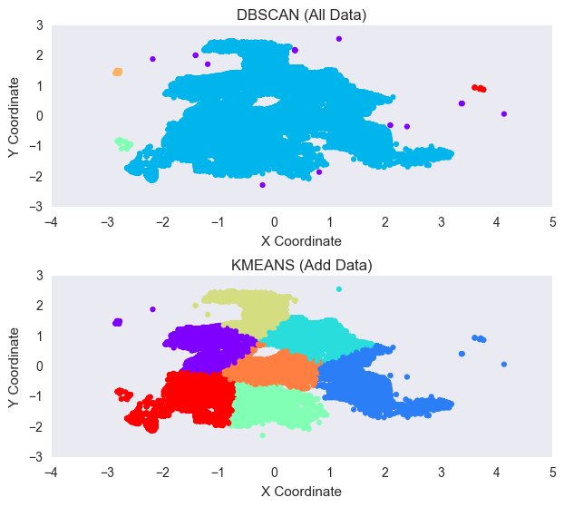

```python
from sklearn.cluster import DBSCAN
from sklearn.cluster import KMeans
from matplotlib import pyplot as plt
from sklearn.preprocessing import StandardScaler

scl_obj = StandardScaler()
scl_obj.fit(df_Plot)

data_scaled = scl_obj.transform(df_Plot)

#data = df_Plot

cls = DBSCAN(eps=0.125, min_samples=6)
#cls = DBSCAN(eps=0.5, min_samples=5) # we are trying different parameters to see if the plot changes, but didn't have any affect.
cls.fit(data_scaled)
dbs_labels = cls.labels_


cls = KMeans(n_clusters=7, random_state=1)
cls.fit(data_scaled)
kmn_labels = cls.labels_

fig = plt.figure(figsize=(12,8))
title = ['DBSCAN (All Data)','KMEANS (Add Data)']

for i,l in enumerate([dbs_labels,kmn_labels]):

    plt.subplot(3,2,2*i+1)
    plt.scatter(data_scaled[:, 0], data_scaled[:, 1], c=l, cmap=plt.cm.rainbow, s=20, linewidths=0)
    plt.xlabel('X Coordinate'), plt.ylabel('Y Coordinate')
    plt.grid()
    plt.title(title[i])


plt.tight_layout()
plt.show()
```

From the figures above, we can see the vastly different results from using each algorithm for clustering the X and Y Coordinates. Using DBSCAN, most instances are clustered in a blob-like cluster with outlying points in their own clusters. It's interesting to see that this method does not distinguish any differences in the range of X and Y coordinates. In other words, it doesn't matter of X is in between -3 to 3 and Y is in between -2 and 3, the cluster encompasses a wide variety of points since it is the most dense in the middle.

Our data may be a bit too dense for DBSCAN to accurately detect more clusters. KMeans performs much better on clustering these variables. You can clearly see 7 different clusters which most likely represent the 7 different Divisions in Dallas.

### Clustering on Theft with X and Y Coordinates

Now let's cluster with only the theft data.

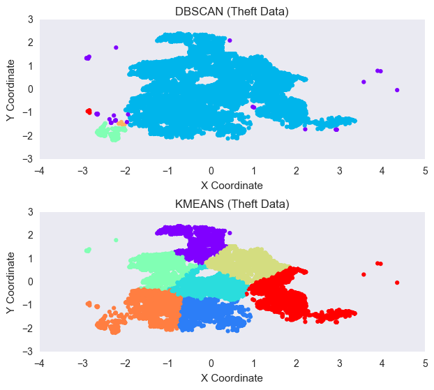

```python
# Plotting for Theft only

# Normalizing Data
scl_obj = StandardScaler()
scl_obj.fit(df_Plot_theft)

data_scaled = scl_obj.transform(df_Plot_theft)

# DBSCAN
cls = DBSCAN(eps=0.125, min_samples=6)
cls.fit(data_scaled)
dbs_labels = cls.labels_

# KMeans
cls = KMeans(n_clusters=7, random_state=1)
cls.fit(data_scaled)
kmn_labels = cls.labels_

# Setup Plot parameters
fig = plt.figure(figsize=(12,8))
title = ['DBSCAN (Theft Data)','KMEANS (Theft Data)']

# Loop to create DBSCAN and KMeans plot
for i,l in enumerate([dbs_labels,kmn_labels]):

    plt.subplot(3,2,2*i+1)
    plt.scatter(data_scaled[:, 0], data_scaled[:, 1], c=l, cmap=plt.cm.rainbow, s=20, linewidths=0)
    plt.xlabel('X Coordinate'), plt.ylabel('Y Coordinate')
    plt.grid()
    plt.title(title[i])


plt.tight_layout()
plt.show()
```

The graphs above show clustering when an incident = theft, with each parameter of KMeans and DBSCAN as specified above. The results are similar with DBSCAN showing one big blob of a cluster with other outlier/possible noise points as their own clusters.

### Drug Related Crimes

Let's take a look at the drug-related crimes using DBSCAN and KMeans clustering. Are there areas wherein these crimes are dense or clustered around?

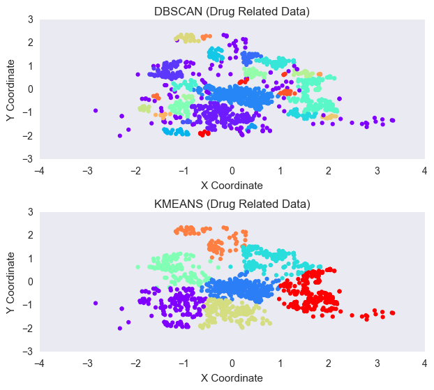

```python
# Plotting drug related crimes

# Normalizing Data
scl_obj = StandardScaler()
scl_obj.fit(df_Plot_theft)

data_scaled = scl_obj.transform(df_Plot_drug)

# DBSCAN
cls = DBSCAN(eps=0.125, min_samples=6)
cls.fit(data_scaled)
dbs_labels = cls.labels_

# KMeans
cls = KMeans(n_clusters=7, random_state=1)
cls.fit(data_scaled)
kmn_labels = cls.labels_

# Setup Plot parameters
fig = plt.figure(figsize=(12,8))
title = ['DBSCAN (Drug Related Data)','KMEANS (Drug Related Data)']

# Loop to create DBSCAN and KMeans plot
for i,l in enumerate([dbs_labels,kmn_labels]):

    plt.subplot(3,2,2*i+1)
    plt.scatter(data_scaled[:, 0], data_scaled[:, 1], c=l, cmap=plt.cm.rainbow, s=20, linewidths=0)
    plt.xlabel('X Coordinate'), plt.ylabel('Y Coordinate')
    plt.grid()
    plt.title(title[i])


plt.tight_layout()
plt.show()
```

Compared to previous results, DBSCAN appears to be performing better but KMeans still appears to produce the best clustering. Kmeans shows 7 different clusters again, each representing each Division. However, DBSCAN may be clustering parts of two divisions together (for example at the botton -1 to 0 location on X) but it may be showing the pattern for different geographical areas wherein a Division line does not matter. In other words, DBSCAN may be picking up that an area in a certain location sees more drug related activity in adjacent parts of 2 Divisions as compared to the other areas of those same Divisions.

Back to Top

## Exceptional Work

Using the KModes method may be counted as exceptional work but we wanted to try using neural networks to make predictions on theft and also create a map visual to give our results for clustering more context.

Back to Top

### Neural Network Using Keras

Keras is a Python library for developing deep learning models. It wraps the libraries Theano and TensorFlow and allowed us to train our Dallas Crime dataset. The dataset was split into 29 input variables (X) as shown below and the output class variable (Y) for IsTheft

The next step was to compile our model. In this step we had to specify our properties to be used to train our network. The loss function we used was the logarithmic loss. Also, the Adam optimization was used and is usually the default algorithm used.

After compiling our model, we fit our model on our loaded data by calling the fit() function on the model. We ran 150 iterations (or epoch) and used 10 for our batch size.

Please note that we limited our model to train on 10 000 observations since our notebook kept crashing when we tried to train our whole dataset

```python
# MLP in Keras
# Source: http://machinelearningmastery.com/tutorial-first-neural-network-python-keras/
from keras.models import Sequential
from keras.layers import Dense
import numpy
# fix random seed for reproducibility
numpy.random.seed(7)


# split into input (X) and output (Y) variables
df_imputed2 = df_imputed[2:10000]

y = df_imputed2['IsTheft']
x = df_imputed2 [['rec_disp_time_m','disp_clear_time_m','Hour','IsDrugRelated',
       'IsGangRelated','IsWeekend','ComplainantAgeRange',
       'ComplainantRace_A','ComplainantRace_B','ComplainantRace_C',
       'ComplainantRace_I','ComplainantRace_L','ComplainantRace_N',
       'ComplainantRace_U','ComplainantRace_W','ComplainantGender_F',
       'ComplainantGender_M','ComplainantGender_U','Division_Central',
       'Division_North Central','Division_NorthEast','Division_NorthWest',
       'Division_South Central','Division_SouthEast','Division_SouthWest',
       'Watch_1','Watch_2','Watch_3','Watch_U']]

x = np.array(x)
y = np.array(y)

# create model
model = Sequential()
model.add(Dense(12, input_dim=29, activation='relu'))
model.add(Dense(29, activation='relu'))
model.add(Dense(1, activation='sigmoid'))
# Compile model
model.compile(loss='binary_crossentropy', optimizer='adam', metrics=['accuracy'])
# Fit the model
model.fit(x, y, epochs=150, batch_size=10)
# evaluate the model
scores = model.evaluate(x, y)
print("\n%s: %.2f%%" % (model.metrics_names[1], scores[1]*100))
```

```
acc: 80.26%
```

## Making Predictions with Our Model

```python
# Source: http://machinelearningmastery.com/tutorial-first-neural-network-python-keras/
from keras.models import Sequential
from keras.layers import Dense
import numpy
# fix random seed for reproducibility
seed = 7
numpy.random.seed(seed)

# split into input (X) and output (Y) variables

df_imputed3 = df_imputed[10000:20000]

y = df_imputed3['IsTheft']
x = df_imputed3 [['rec_disp_time_m','disp_clear_time_m','Hour','IsDrugRelated',
       'IsGangRelated','IsWeekend','ComplainantAgeRange',
       'ComplainantRace_A','ComplainantRace_B','ComplainantRace_C',
       'ComplainantRace_I','ComplainantRace_L','ComplainantRace_N',
       'ComplainantRace_U','ComplainantRace_W','ComplainantGender_F',
       'ComplainantGender_M','ComplainantGender_U','Division_Central',
       'Division_North Central','Division_NorthEast','Division_NorthWest',
       'Division_South Central','Division_SouthEast','Division_SouthWest',
       'Watch_1','Watch_2','Watch_3','Watch_U']]

x = np.array(x)
y = np.array(y)

# create model
model = Sequential()
model.add(Dense(12, input_dim=29, init='uniform', activation='relu'))
model.add(Dense(29, init='uniform', activation='relu'))
model.add(Dense(1, init='uniform', activation='sigmoid'))
# Compile model
model.compile(loss='binary_crossentropy', optimizer='adam', metrics=['accuracy'])

# calculate predictions
predictions = model.predict(x)
# round predictions
rounded = [round(x[0]) for x in predictions]
print(rounded)
```

[output not shown]

The predictions for the IsTheft response variable is listed above

Back to Top

### Theft Incidents on the Map

```python
import plotly
plotly.tools.set_credentials_file(username='nimrack', api_key='LfogZvIVrCHiv98rNCQU')
```

```python
#subset of THEFT crime in Dallas
#http://stackoverflow.com/questions/3925614/how-do-you-read-a-file-into-a-list-in-python
#https://plot.ly/python/scattermapbox/#multiple-markers
import plotly.plotly as py
import pandas as pd
from plotly.graph_objs import *
df = pd.read_csv('/Users/sharonteo/Downloads/Dallas_Community.csv')
df1=pd.read_csv('/Users/sharonteo/Downloads/Dallas_CommunityH.csv')
df2=pd.read_csv('/Users/sharonteo/Downloads/Dallas_CommunityM.csv')
df3=pd.read_csv('/Users/sharonteo/Downloads/Dallas_CommunityL.csv')


limits = [(0,2),(3,10),(11,20),(21,50),(50,3000)]

mapbox_access_token = 'pk.eyJ1IjoibmltcmFjayIsImEiOiJjajI0YXJnb2UwMDFlMnFwYzRjbTB3aDU3In0.oyBAAeAXG5xg86N9um28Yg'
AllTheft=[]


scale= 88
df_sub=df
data = Data([
    Scattermapbox(
        lon = df_sub['Long'],
        lat = df_sub['Lat'],
        name="All Theft",
        hoverinfo="text",
        mode='markers+text',
        marker=Marker(
            size=df_sub['Count']/scale,
            color=df_sub['Count']/scale,
            cmax=(3000/88),
            cmin=(100/88),
            colorscale="Portland",
        ),
        text=df_sub['Community'],
    )
])

layout = dict(Layout(
    autosize=True,
    hovermode='closest',
    showlegend=True,
    mapbox=dict(
        accesstoken=mapbox_access_token,
        bearing=0,
        center=dict(
            lat=32.8,
            lon=-96.8
        ),
        pitch=0,
        zoom=9
    ),
))

fig = dict(data=data, layout=layout)
py.iplot(fig, filename='Dallas Mapbox', validate=False)
```

```
High five! You successfuly sent some data to your account on plotly. View your plot in your browser at https://plot.ly/~nimrack/0 or inside your plot.ly account where it is named 'Dallas Mapbox'
```

[interactive chart not shown]

Back to Top

## Conclusion

We then created a visualization that showed the recorded dispatch time versus the hour after both variables were normalized to take into account wide range of differences in each. This resulted in four different clusters- two different clusters for a fast dispatch time according to the hour of the day, one for a medium dispatch time and one for a slow dispatch time regardless of the hour. Graphing clusters of a couple different complainant races versus age showed several different clusters be normalized age. The ranges of these clusters were the same.

KModes was used to show what types of clustering results using categorical data. Various details of the age and race of a complainant as well as the Division, Watch, Hour, and UCR Offense Description comprised these clusters. Seeing the details of these results provided us with more detailed descriptions of what is in each cluster.

Next we explored how the X and Y coordinates cluster with all the data, just the theft data, and drug related crimes. We saw that the Kmeans method identified the 7 different Divisions in Dallas for each category with a cluster for each division. On the other hand, DBSCAN showed one large blob of a cluster for all data and theft but showed a bit more detail in the drug related crimes. DBSCAN may be clustering on the different areas where drug related incidents are occurring, regardless of a Division line.

Our results give the Dallas PD insight to all of the points mentioned above and most importantly the locations of incidents and how they cluster.